# Angewandte Forschungsprojekte

## Inhalt

- Rückblick TubeCam
- Schwerpunkte 2019/2020
  - Weiterentwicklung Nachweismethodik
  - Angepasstes Versuchdesign Erfolgskontrolle
  - Räuber-Beute Dynamik
  - Erhebung von Kleinstrukturen LiDAR
  - Nistkastenmonitoring

## Rückblick TubeCam

- Rückblick TubeCam
- Schwerpunkte 2019/2020
  - Weiterentwicklung Nachweismethodik
  - Angepasstes Versuchdesign Erfolgskontrolle
  - Räuber-Beute Dynamik
  - Erhebung von Kleinstrukturen LiDAR
  - Nistkastenmonitoring

## Ausangslage (2016)

Aktuell ist der Nachweis von Kleinmusteliden sehr aufwendig

- Spurentunnel sind schwer transportierbar
- Tinte aufwendig in der Herstellung / Lagerung
- Wöchentliche Besuche im Feld nötig
- Ausfälle durch Witterung (Regenfälle / Trockenheit)
- Auswertung benötigt viel Erfahrung / Expertenwissen
- Daten sind von geringer Auflösung (nur Präsenzdaten)
- Daten lassen sich schwer Teilen und Archivieren

## Entscheid (2016)

Entwicklung einer Nachweismethodik mit folgenden Zielen:

- Geringerer Zeitaufwand und geringere Gesamtkosten
- Höhere Datenqualität und grössere Wissensausbeute
- Tierschutzgerecht
- Ermöglicht zuverlässige Datenerhebung und -auswertung durch Laien

## Vision

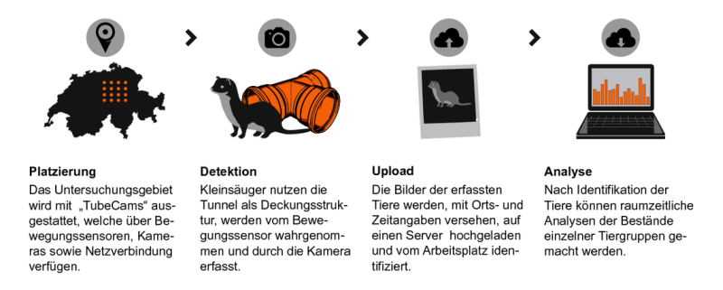

## Zeitplan

## Otterzentrum Hankensbüttel

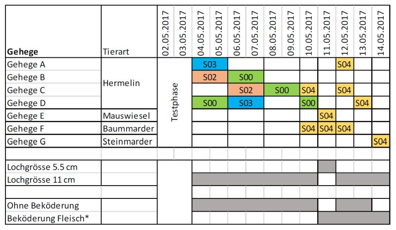

## Otterzentrum Hankensbüttel

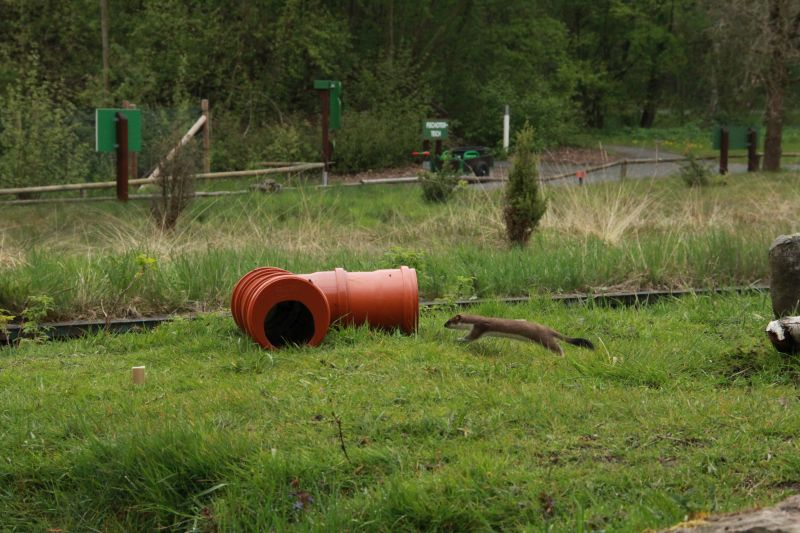

## Otterzentrum Hankensbüttel

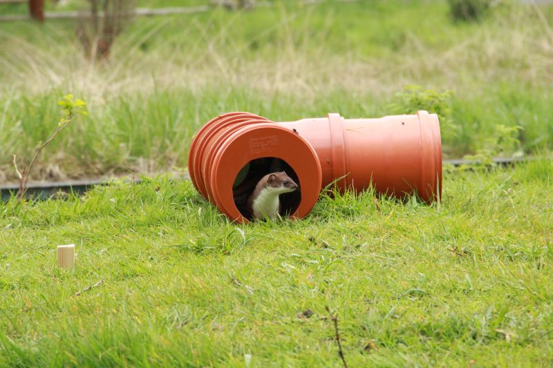

## Otterzentrum Hankensbüttel

[figure not shown]

## Otterzentrum Hankensbüttel

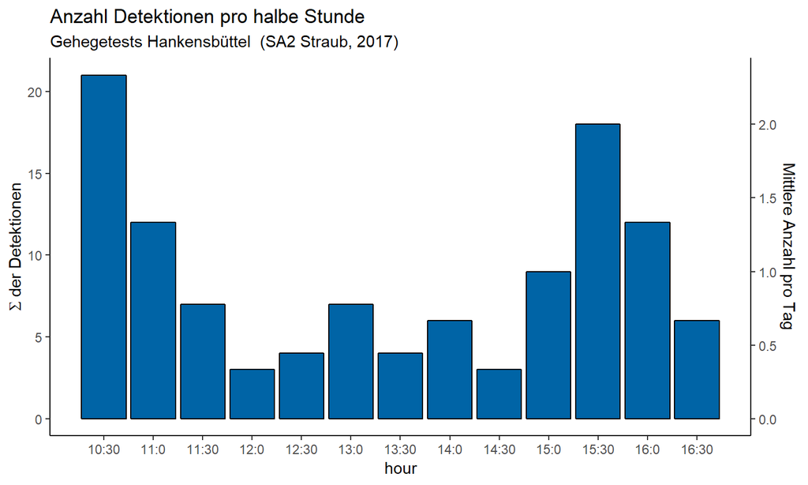

## Otterzentrum Hankensbüttel

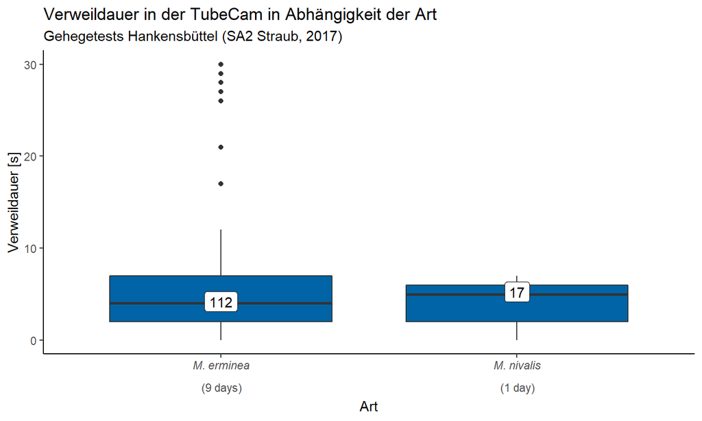

## Otterzentrum Hankensbüttel

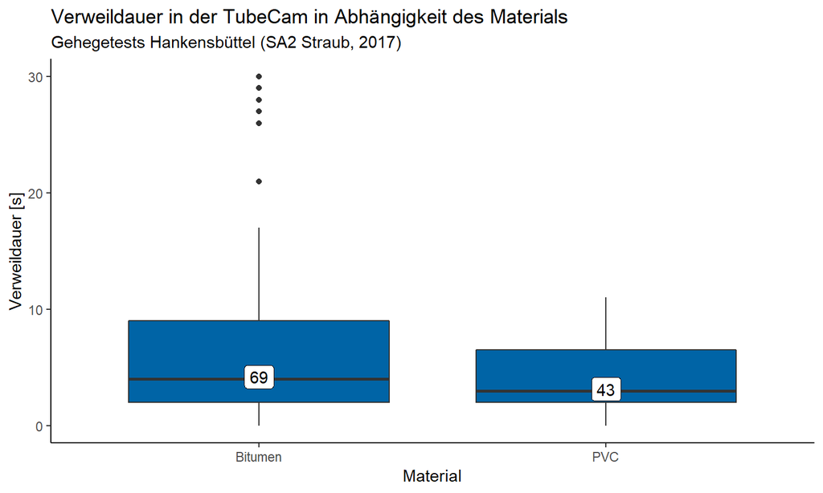

## Zeitplan

## Feldversuch Au, ZH (2017)

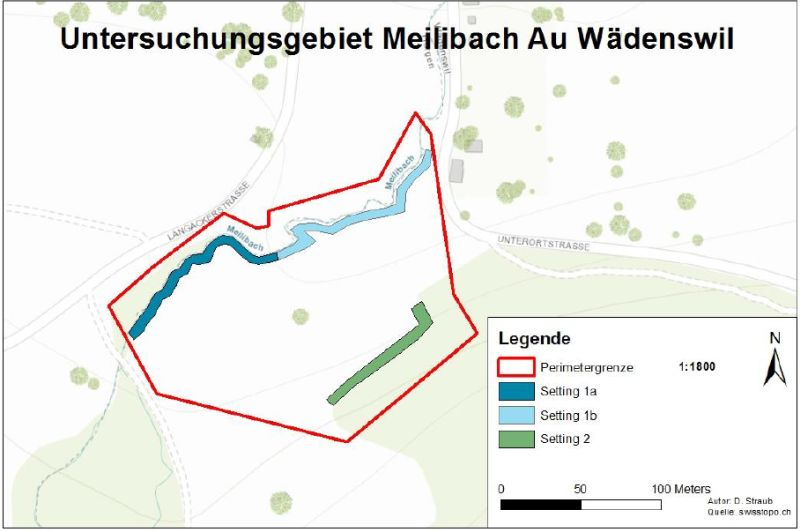

## Feldversuch Au, ZH (2017)

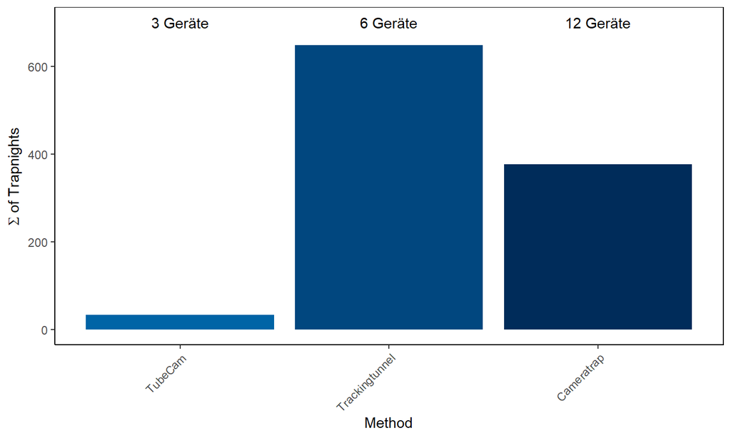

## Feldversuch Au, ZH (2017)

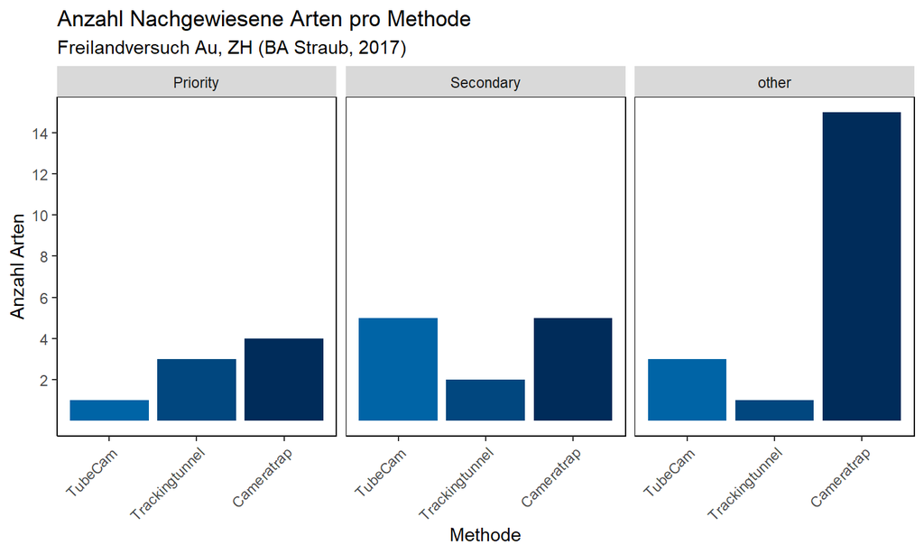

## Feldversuch Au, ZH (2017)

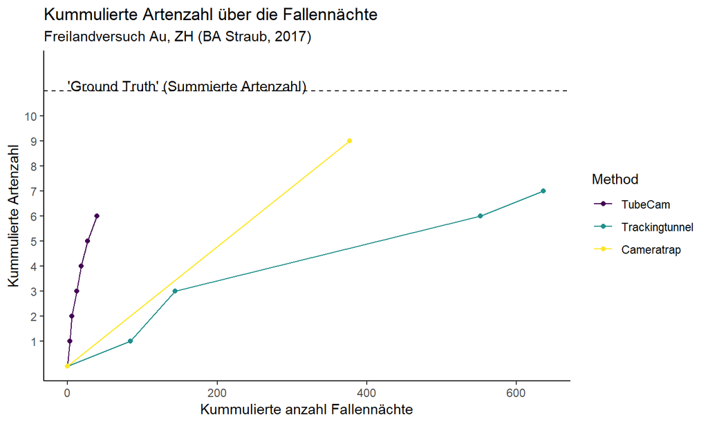

## Zeitplan

## Feldversuch Au, ZH (2018)

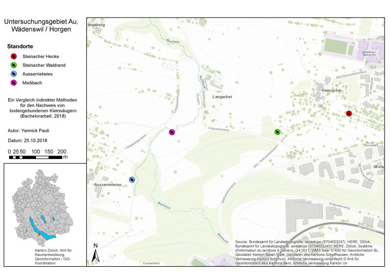

## Feldversuch Au, ZH (2018)

[figure not shown]

## Feldversuch Au, ZH (2018)

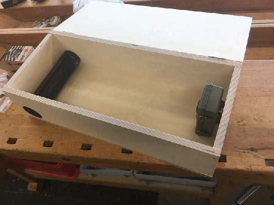

## Feldversuch Au, ZH (2018)

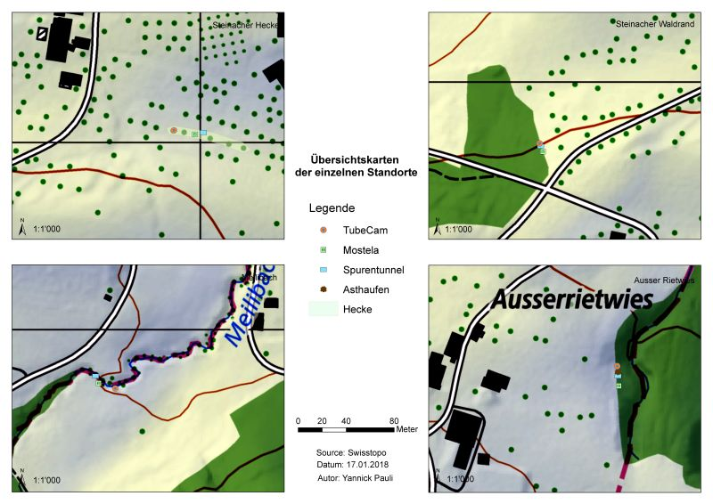

## Feldversuch Au, ZH (2018)

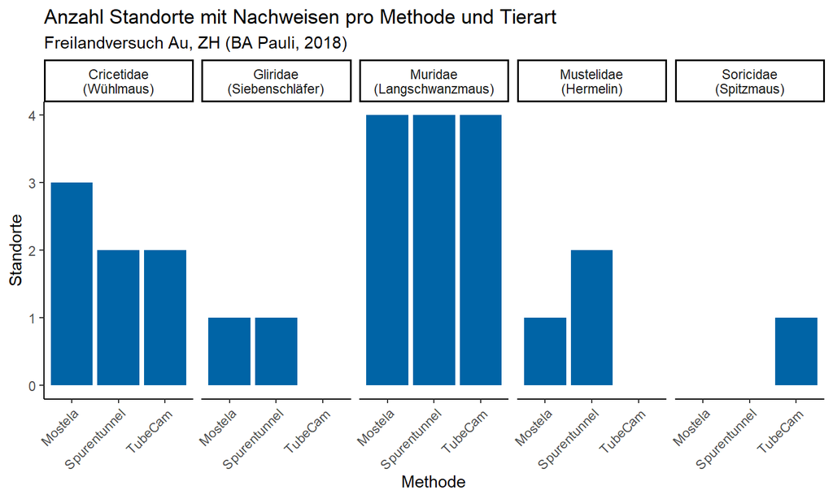

## Feldversuch Au, ZH (2018)

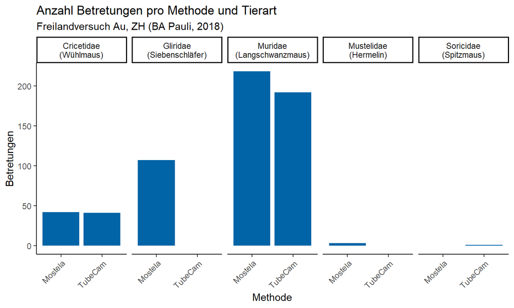

## Feldversuch Au, ZH (2018)

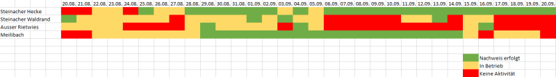

## Feldversuch Au, ZH (2018)

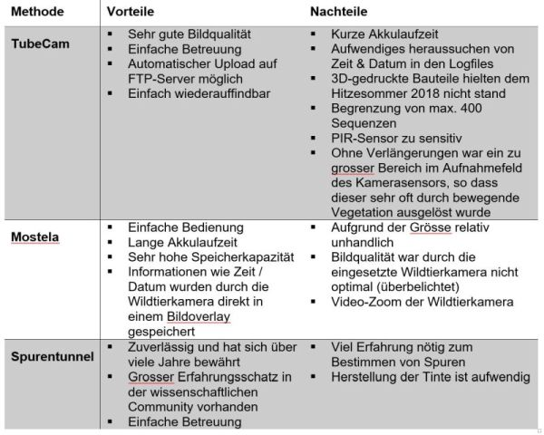

## Feldversuch Rothenthurm (2018)

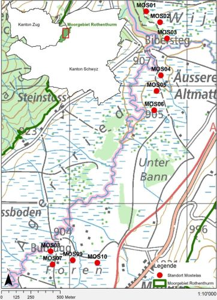

Aus Jud (2018): Potenzial von Fotofallen-Boxen für das Kleinsäuger-Monitoring. Bachelorarbeit. ZHAW, Wädenswil.

## Feldversuch Rothenthurm (2018)

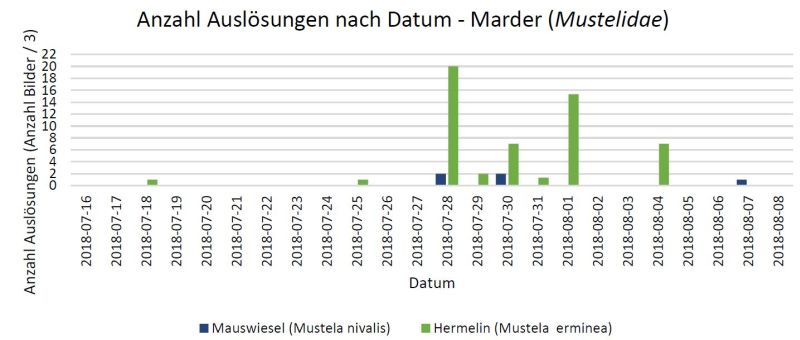

## Feldversuch Rothenthurm (2018)

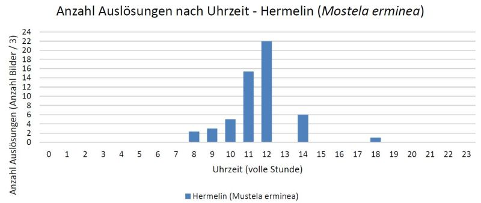

Aus Jud (2018): Potenzial von Fotofallen-Boxen für das Kleinsäuger-Monitoring. Bachelorarbeit. ZHAW, Wädenswil.

## Feldversuch Rothenthurm (2018)

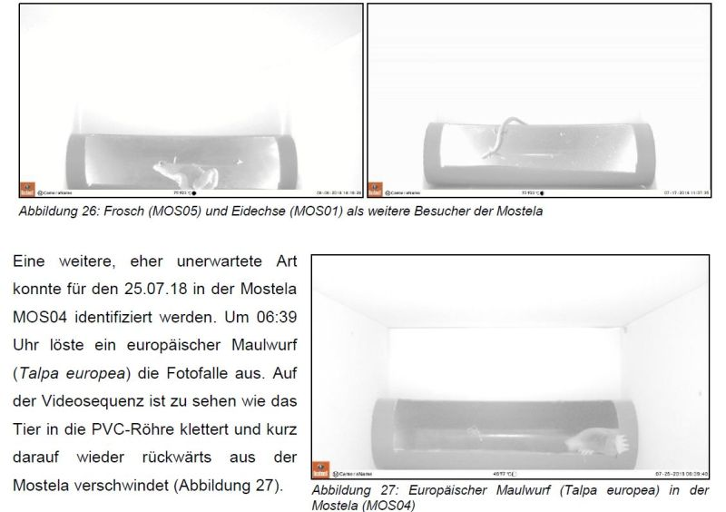

Aus Jud (2018): Potenzial von Fotofallen-Boxen für das Kleinsäuger-Monitoring. Bachelorarbeit. ZHAW, Wädenswil.

## Feldversuch Rothenthurm (2018)

[figure not shown]

Aus Jud (2018): Potenzial von Fotofallen-Boxen für das Kleinsäuger-Monitoring. Bachelorarbeit. ZHAW, Wädenswil.

## Feldversuch Rothenthurm (2018)

[figure not shown]

Aus Jud (2018): Potenzial von Fotofallen-Boxen für das Kleinsäuger-Monitoring. Bachelorarbeit. ZHAW, Wädenswil.

## Fazit

- Der Bedarf an alternativen Methoden scheint gross zu sein
- Es gab relativ schnell eine Liste potentieller Abnehmer:
  - Nationalpark Harz (DE)
  - Schweizer Nationalpark
  - Ökobüros CH und NL
  - Vogelwarte, Pronatura

## Fazit

- Technisch haben wir relativ schnell viel erreichen können
- Tests unter Laborbedingungen (Hermelin-Gehege) waren ebenfalls viel versprechend
- die ersten Freilandversuche (2017) zeigten jedoch, dass das Gerät noch sehr weit davon entfernt ist, praxistauglich zu sein
- auch im zweiten Freilandversuch (2018) haben technische Probleme die Datenerhebung dominiert

## Take Home Message

- Wir behalten die Ziele (2016) zur Entwicklung von Nachweismethoden bei
- Wir verfolgen eine neue Strategie und setzen auf die Nutzung bestehender Wildtierkameras
- Die Entwicklung einer eigenen Kamera (TubeCam) wird nicht mehr weiter verfolgt
- Aktuell läuft eine Bachelorarbeit zu diesem Thema

## Angepasstes Versuchdesign Erfolgskontrolle

- Rückblick TubeCam
- Schwerpunkte 2019/2020
  - Weiterentwicklung Nachweismethodik
  - Angepasstes Versuchdesign Erfolgskontrolle
  - Räuber-Beute Dynamik
  - Erhebung von Kleinstrukturen LiDAR
  - Nistkastenmonitoring

## Synthese aus Spurentunnel Erhebungen

- Wir wissen, dass wir mit jeder Erhebungsmethode die Tiere mit nur sehr geringer Wahrscheinlichkeit detektieren
- Dieses wissen möchte ich stärker in die Planung und Kommunikation unserer Erfolgskontrollen einfliessen lassen
- Erster Ansatz: Berechnung der Detektionswahrscheinlichkeit in Abhängigkeit der Zeit

## Erste Auswertung

| Kanton | KM2 | Tunnel | Woche0 | Woche1 | Woche2 | Woche3 | Woche4 | Woche5 |
| --- | --- | --- | --- | --- | --- | --- | --- | --- |
| AG | 656262 | 1 | 0 | 0 | 0 | 1 | 0 | 0 |
| AG | 663264 | 1 | 0 | 0 | 0 | 0 | 0 | 0 |
| AG | 663264 | 2 | 0 | 0 | 0 | 0 | 1 | 0 |
| BE | 578234 | 1 | 0 | 0 | 0 | 0 | 0 | 0 |
| BE | 578234 | 2 | 0 | 0 | 0 | 0 | 1 | 1 |
| BE | 580232 | 1 | 0 | 0 | 0 | 0 | 0 | 0 |
| BE | 593232 | 1 | 0 | 0 | 0 | 0 | 0 | 0 |
| BE | 593232 | 2 | 0 | 0 | 0 | 0 | 0 | 0 |
| BE | 598236 | 1 | 0 | 0 | 0 | 1 | 0 | 0 |
| BE | 598236 | 2 | 0 | 0 | 0 | 0 | 0 | 1 |

## Logistische Regression

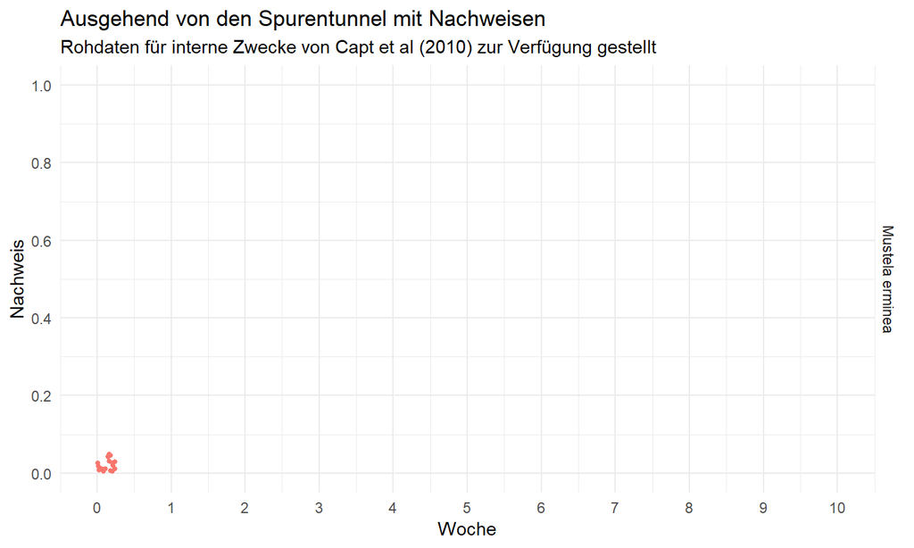

## Logistische Regression

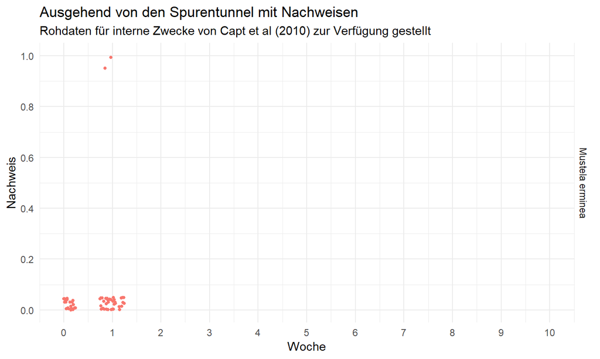

## Logistische Regression

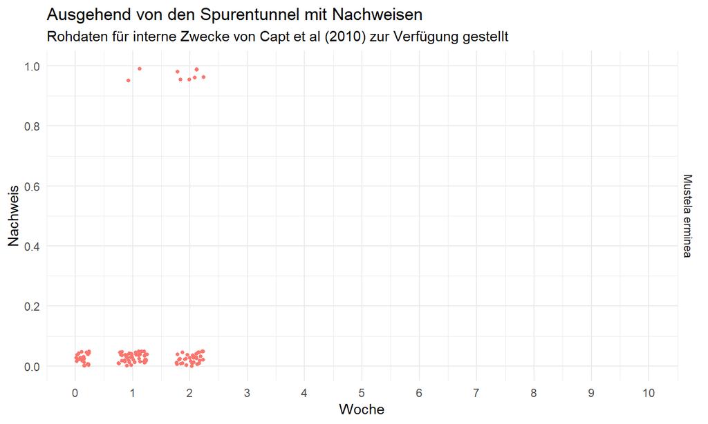

## Logistische Regression

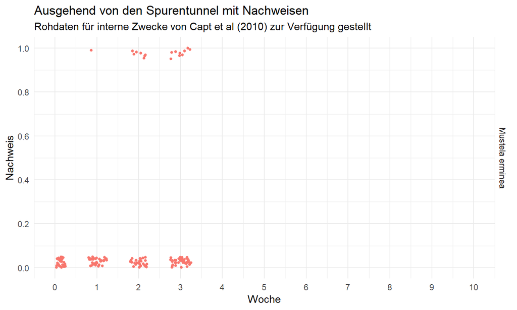

## Logistische Regression

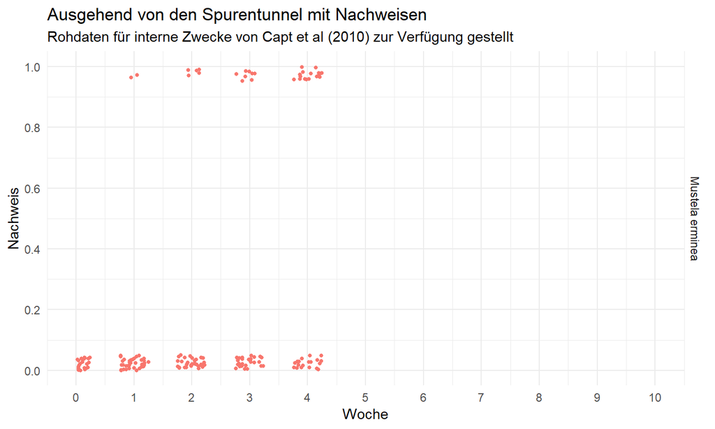